# Untitled

Kristin Marshall

November 18, 2018

# Regression approach to understanding Hamel et al.’s survey configuration results

The question we’re trying to answer here is what can we learn from the results of the existing analyses of assessment models, in terms of the factors that influence how assessment output changes when survey data changes.

## Data input

The primary output is what Hamel et al. present in their analysis (percent change in OFL by species and survey reduction type. I smashed the information in the tables in that manuscript together with some factors from the stock assessment prioritization to see what predictors might align with the responses in Owen’s paper.

### Response

Percent change in OFL is the only response used here.

Need to add the change in the survey cv for each reduction type– this is discussed in the results text of the paper, but only presented by way of figures. Survey cv would be a second response.

### Predictors

Predictors that might makes sense to look at include things that capture how well the species is surveyed (number of postive hauls, habitat preference, life history type), as well as factors that influence how the assessment for that species might respond due to reductions in observations (generation time, recruitment variability)

From the survey prioritization: Recruitment CV, mean age in the catch, percent attainment, depletion, PSA, number of commercial length samples, commercial otolith samples, survey lengths, survey age-structures

Others: number of positive hauls, status quo OFL, species type, assessment type, reduction type

## Regression

Tried each predictor one at a time and compared AICs and the significance of coefficients. Nothing is significant. None of the single-predictor models result in an AIC score better than a null model. Below are plots of each variable

```r
lm2=glm(OFL.norm~1, data=scon.dat)
summary(lm2)
```

```
##
## Call:
## glm(formula = OFL.norm ~ 1, data = scon.dat)
##
## Deviance Residuals:
##      Min        1Q    Median        3Q       Max
## -0.82436  -0.16936  -0.02436   0.14064   2.02564
##
## Coefficients:
##             Estimate Std. Error t value Pr(>|t|)
## (Intercept) -0.06564    0.05521  -1.189     0.24
##
## (Dispersion parameter for gaussian family taken to be 0.1676621)
##
##     Null deviance: 9.0538  on 54  degrees of freedom
## Residual deviance: 9.0538  on 54  degrees of freedom
## AIC: 60.855
##
## Number of Fisher Scoring iterations: 2
```

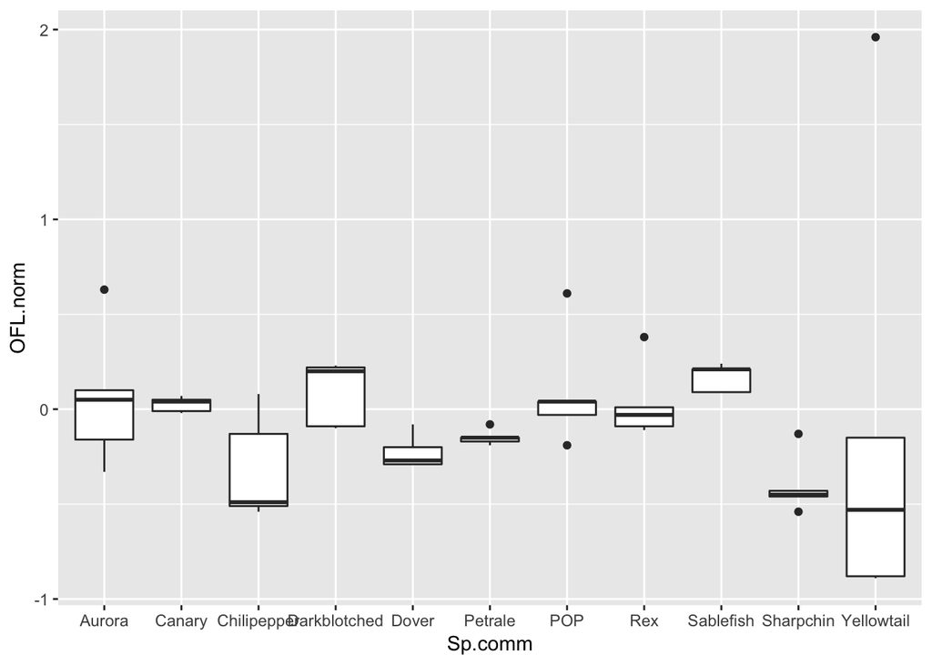

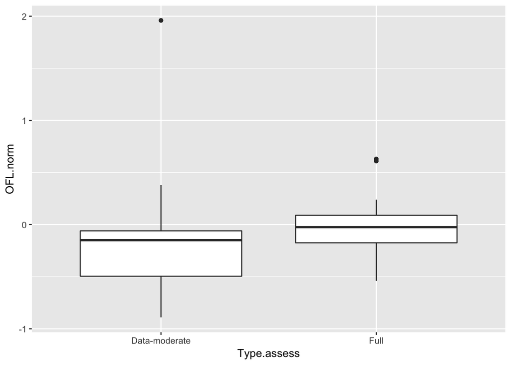

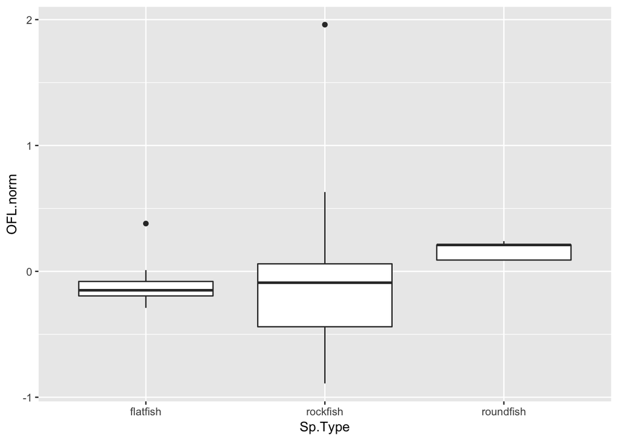

```r
for(i in c(1,4,5)){
  grp.plot<-ggplot(data=scon.dat, aes(scon.dat[,i],OFL.norm)) +
    geom_boxplot() +
    xlab(names(scon.dat)[i])
  print(grp.plot)

}
```

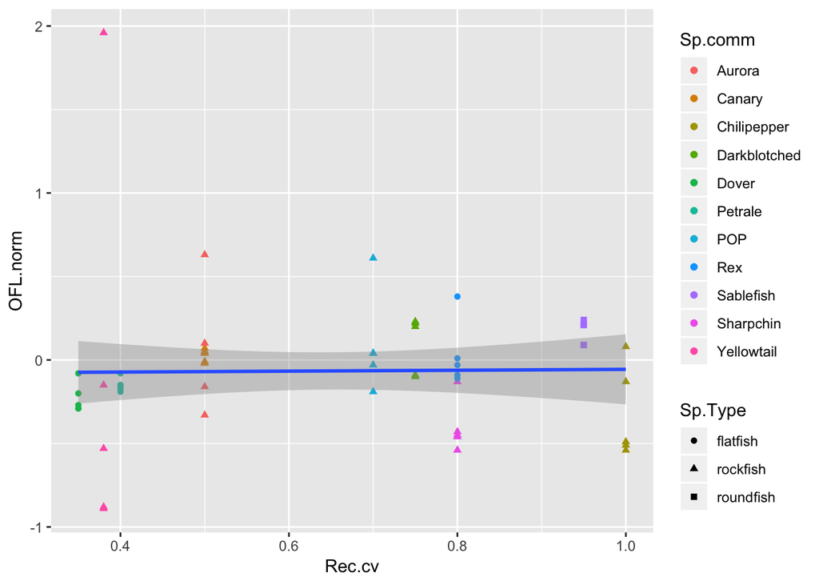

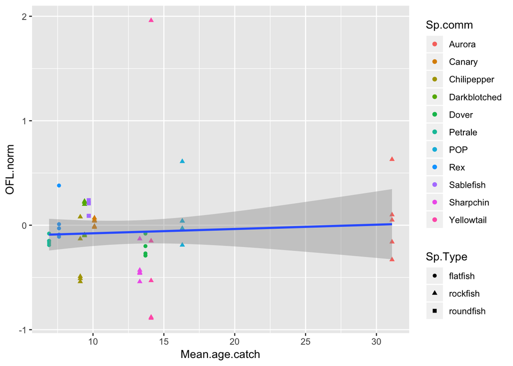

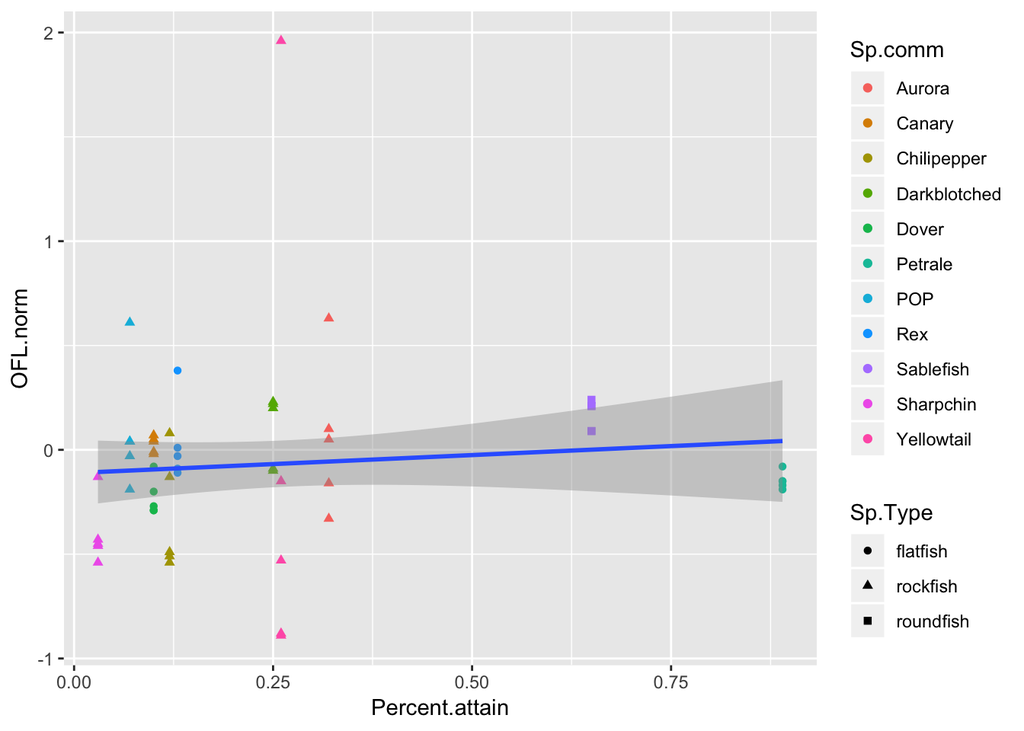

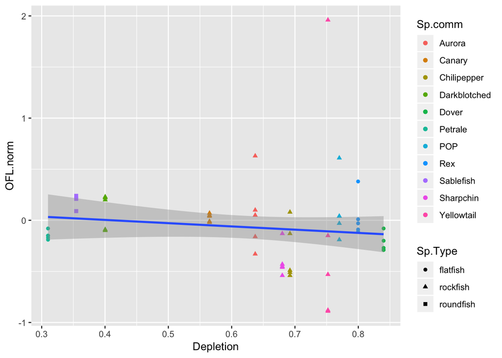

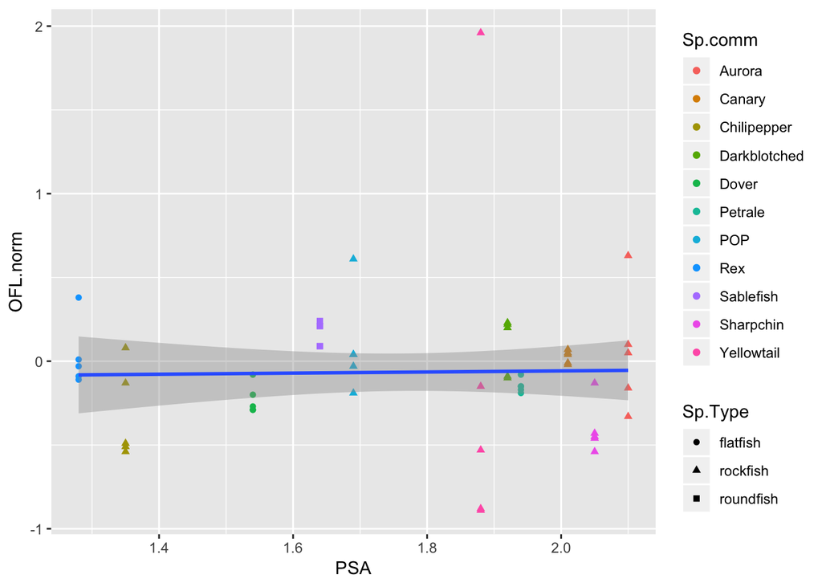

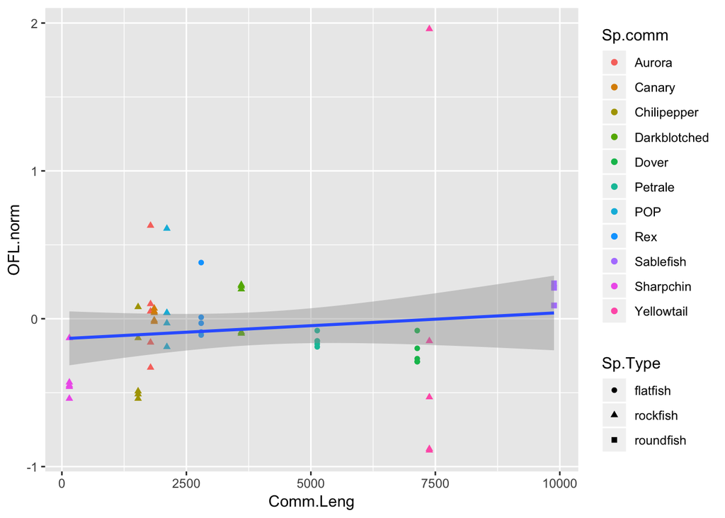

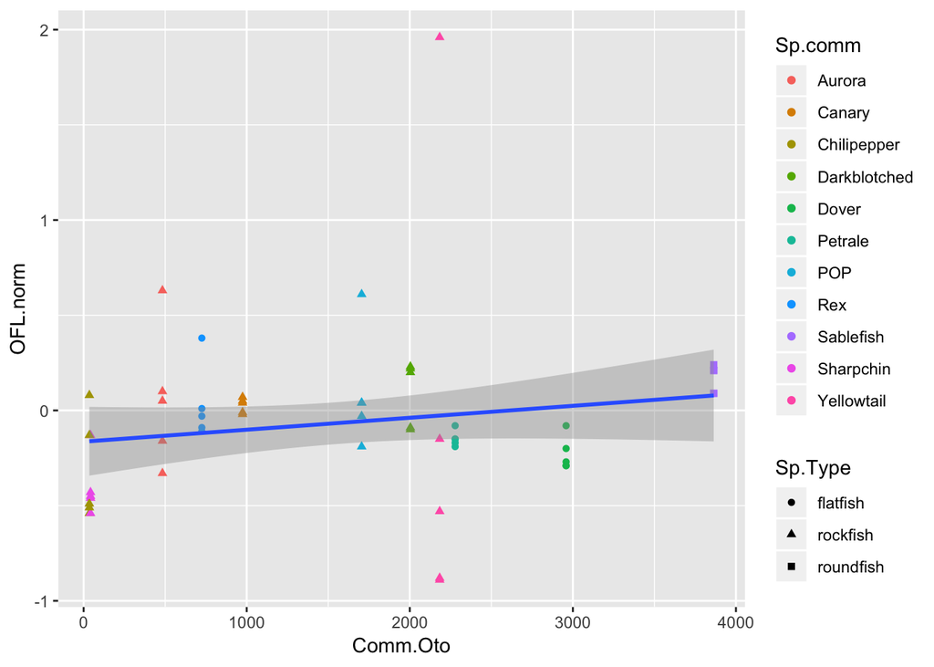

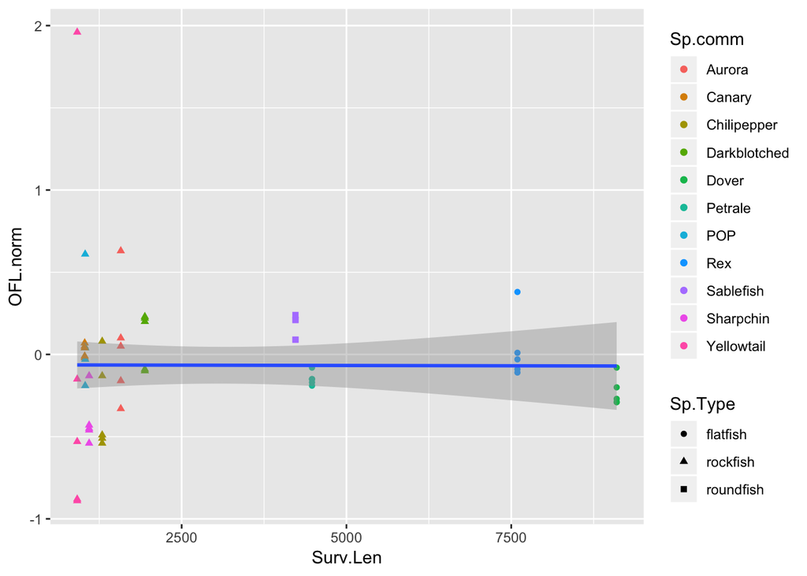

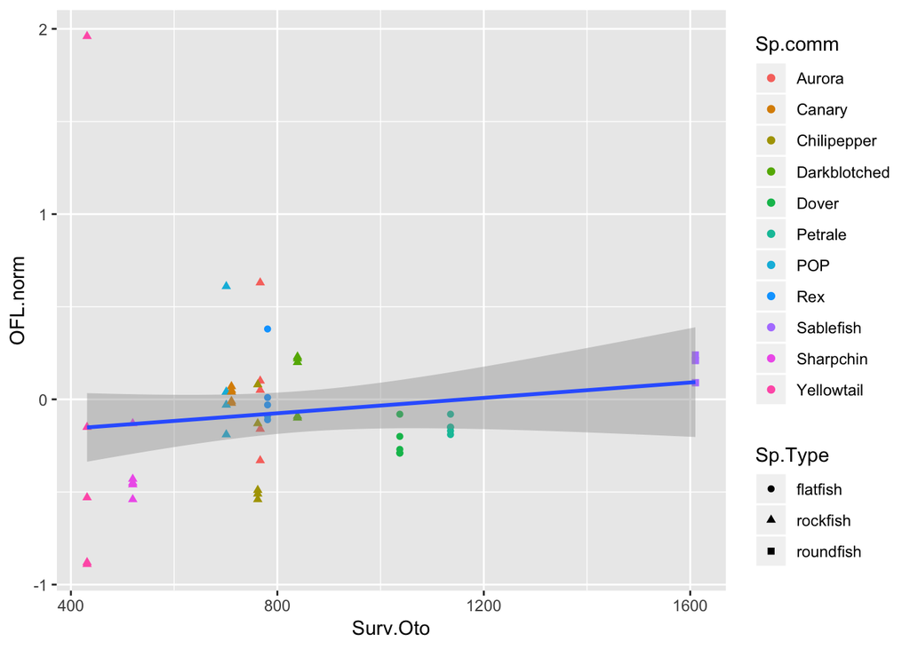

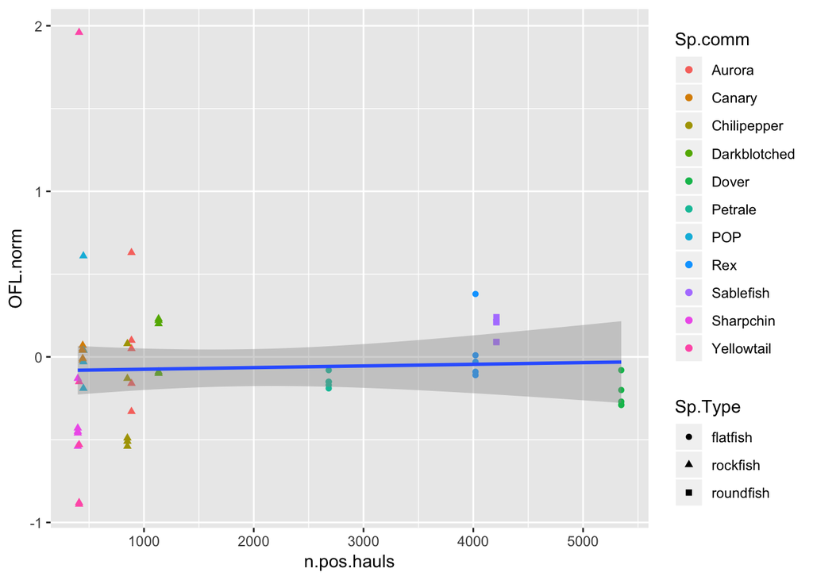

```r
for (i in c(6:14,27)) {
  #lm1=glm(OFL.norm~scon.dat[,i], data=scon.dat)
  #summary(lm1)
  reg.plot<-ggplot(data=scon.dat, aes(scon.dat[,i],OFL.norm)) +
    geom_point(aes(color=Sp.comm, shape=Sp.Type)) +
    geom_smooth(method=lm, se=TRUE) +
    xlab(names(scon.dat)[i])
  print(reg.plot)
}
```

```r
#lm2=glm(OFL.norm~1, data=scon.dat)

#summary(lm2)

#lm3=glm(OFL.norm~Rec.cv+ Mean.age.catch, data=scon.dat)
```

## Extrapoloate regression results to new species

There are no results to extrapolate!